# CALIDAD DEL AGUA DEL RIO RIMAC

EQUIPO 3

31/3/2021

**UNIVERSIDAD NACIONAL AGRARIA LA MOLINA**

**PROFESOR: JESUS SALINAS**

**FACULTAD EYP**

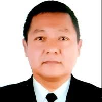

[figure not shown]

**INTEGRANTES**

LUIS EDGAR GUTIERREZ SALDANA

CHRISTIAN CRUZATE

JENNY MONTOYA

[figure not shown]

# 2.OBJETIVOS

El objetivo principal de este estudio es determinar patrones de variación temporal de la calidad de agua en el sector de la bocatoma de La Atarjea, Río Rímac. Los objetivos específicos son:

1. Identificar patrones temporales de variación de la calidad de agua.
2. Examinar la variación temporal de cada uno de los parámetros de la calidad de agua.
3. Identificar los parámetros de calidad de agua más importantes o relevantes.
4. Identificar relaciones entre parámetros de calidad de agua.

# 3.APLICANDO CLUSTER JERARQUICO

```r
library(readxl)
datosc <- read_excel("dato.24variables.84obs.xlsx")
```

```r
str(datosc)
```

```
## tibble [84 x 25] (S3: tbl_df/tbl/data.frame)
##  $ meses : POSIXct[1:84], format: "2009-01-01" "2009-02-01" ...
##  $ Caudal: num [1:84] 38.9 69 71.4 46.8 19.9 18.8 18.3 19.3 20.6 20.8 ...
##  $ Temp  : num [1:84] 18.6 21.6 19.6 20.9 18.9 ...
##  $ pH    : num [1:84] 7.7 7.86 7.92 7.96 8.11 ...
##  $ Turb  : num [1:84] 47.8 322 739.3 90.5 18 ...
##  $ CE    : num [1:84] 467 367 379 419 576 ...
##  $ OD    : num [1:84] 8.68 9.25 8.57 8.5 8.8 ...
##  $ SD    : num [1:84] 408 247 281 225 416 ...
##  $ Alcal : num [1:84] 90.5 78 82.5 102.8 126 ...
##  $ DT    : num [1:84] 213 163 172 186 263 ...
##  $ CLs   : num [1:84] 13.29 8.95 10.41 12.3 20 ...
##  $ SO4   : num [1:84] 138 114 102 115 157 ...
##  $ NO3   : num [1:84] 3.2 2.37 3.79 3.28 4.61 ...
##  $ NO2   : num [1:84] 0.17 0.0605 0.1133 0.1552 0.0645 ...
##  $ PO4   : num [1:84] 0.2392 0.0158 0.0795 0.1878 0.2702 ...
##  $ Cu    : num [1:84] 0.036 0.0255 0.04 0.022 0.0122 ...
##  $ Al    : num [1:84] 1.768 2.241 1.489 0.766 0.245 ...
##  $ Fe    : num [1:84] 1.837 2.882 7.33 0.992 0.146 ...
##  $ Mn    : num [1:84] 0.1062 0.099 0.205 0.0612 0.0145 ...
##  $ Pb    : num [1:84] 0.0262 0.0362 0.0358 0.0262 0.0112 ...
##  $ Cd    : num [1:84] 0.001725 0.002725 0.0024 0.000575 0.00155 ...
##  $ Zn    : num [1:84] 0.446 0.562 0.268 0.161 0.182 ...
##  $ As    : num [1:84] 0.0445 0.0225 0.0275 0.0232 0.0225 ...
##  $ Coto  : num [1:84] 190298 272892 215381 297967 400188 ...
##  $ Cote  : num [1:84] 76752 151936 87032 125867 152662 ...
```

Convirtiendo en un dataframe:

```r
datosc=as.data.frame(datosc)
```

```r
rownames(datosc)<- datosc$meses
```

Eliminanos la variable meses(cualitativa)

```r
datosc$meses=NULL
head(datosc,3)
```

|  | Caudal | Temp | pH | Turb | CE | OD | SD | Alcal | DT | CLs | SO4 | NO3 | NO2 | PO4 | Cu | Al | Fe | Mn | Pb | Cd | Zn | As | Coto | Cote |
| --- | --- | --- | --- | --- | --- | --- | --- | --- | --- | --- | --- | --- | --- | --- | --- | --- | --- | --- | --- | --- | --- | --- | --- | --- |
| 2009-01-01 | 38.9 | 18.650 | 7.6975 | 47.800 | 466.75 | 8.675 | 408 | 90.5 | 213.25 | 13.2925 | 138.00 | 3.19700 | 0.17000 | 0.23925 | 0.0360 | 1.76775 | 1.83700 | 0.10625 | 0.02625 | 0.001725 | 0.44600 | 0.0445 | 190298.1 | 76752.26 |
| 2009-02-01 | 69.0 | 21.575 | 7.8550 | 321.990 | 366.75 | 9.250 | 247 | 78.0 | 163.00 | 8.9475 | 113.50 | 2.37175 | 0.06050 | 0.01575 | 0.0255 | 2.24100 | 2.88250 | 0.09900 | 0.03625 | 0.002725 | 0.56175 | 0.0225 | 272891.9 | 151935.64 |
| 2009-03-01 | 71.4 | 19.625 | 7.9250 | 739.265 | 379.00 | 8.575 | 281 | 82.5 | 172.50 | 10.4100 | 101.75 | 3.78750 | 0.11325 | 0.07950 | 0.0400 | 1.48850 | 7.33025 | 0.20500 | 0.03575 | 0.002400 | 0.26825 | 0.0275 | 215381.2 | 87032.18 |

**ANALISIS EXPLORATORIO**

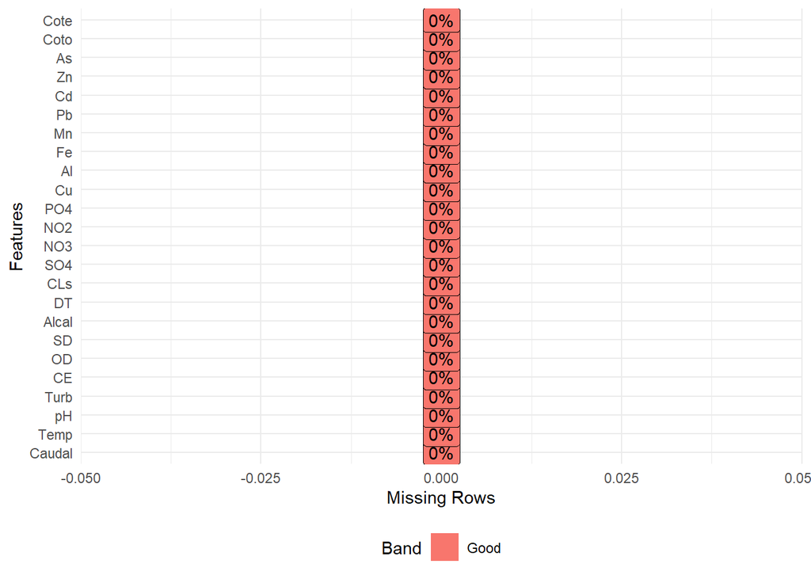

```r
#Verificando si hay valores faltantes:
#Detectando y graficando los % de datos perdidos
#No hay valores perdidos en ninguna variable
library(DataExplorer)
library(ggplot2)
plot_missing(datosc,ggtheme=theme_minimal())
```

**ANALISIS DESCRIPTIVO**

```r
library(zoo)
library(PerformanceAnalytics)
```

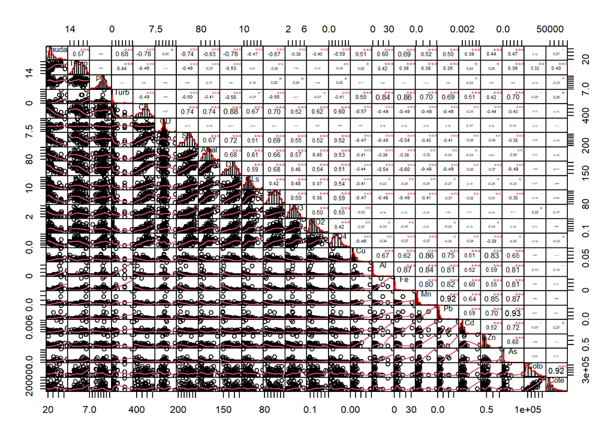

```r
library(xts)
library(graphics)
#pearson "escala de intervalo"#es mejor si el tamaño de muestra es mas grande.
chart.Correlation(datosc, histogram=TRUE, method = c("pearson"), pch=20)
```

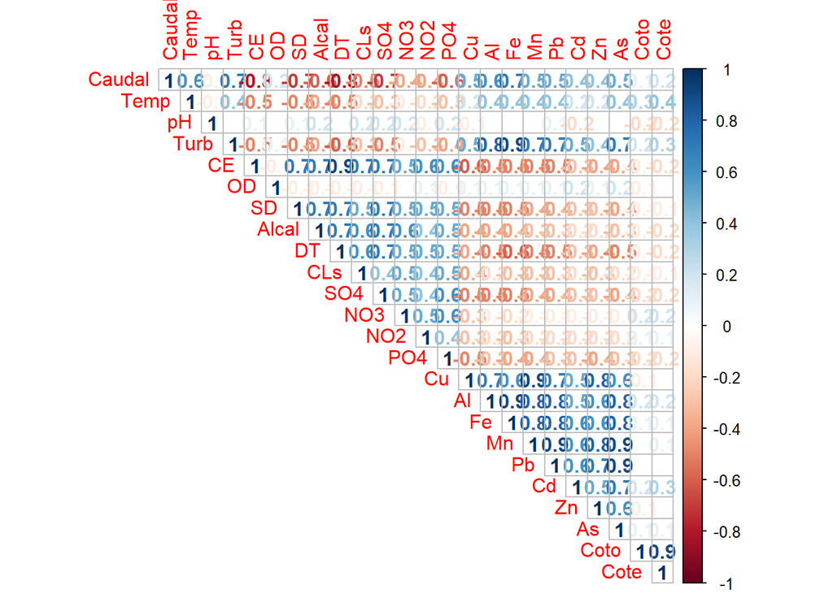

```r
library(corrplot)
correlacion<-round(cor(datosc), 1)

corrplot(correlacion, method="number", type="upper")
```

Se observa que 20 variables sus coeficientes correlacion de pearson es alto, es decir las variables se encuentran altamente correlacionados excepto las variables (PH),oxigeno disuelto(OD) ,coliformes termotolerables(cote)y coliformes totales(coto) son las que tienen una menor correlacion de pearson, es decir estas ultimas variables se encuentran poco correlacionados con las demas variables.

Deseamos que exista una alta correlacion entre las variables para poder aplicar la tecnica multivariada no supervisada ANALISIS FACTORIAL.

```r
#estandarizamos los datos porque las variables se encuentran en diferentes escalas
 datosc <- as.data.frame(scale(datosc))
```

**CLUSTER JERARQUICO AGLOMERATIVO**

Distancia euclidiana y metodo de enlace Ward.D2

```r
#-----------------------------------
#calculando la matriz de disimilaridad




d <- dist(datosc, method = "euclidean")

#el metodo ward.d2 ,para reconstruir la matriz distancia
res.hc <- hclust(d, method = "ward.D2" )
```

```r
res.hc$merge
```

```
##       [,1] [,2]
##  [1,]  -32  -34
##  [2,]  -81  -82
##  [3,]  -79  -80
##  [4,]  -10  -11
##  [5,]  -69  -70
##  [6,]  -42  -43
##  [7,]  -47  -83
##  [8,]  -71    3
##  [9,]  -44  -45
## [10,]  -20  -31
## [11,]  -66  -67
## [12,]  -33    1
## [13,]   -1  -37
## [14,]  -48  -60
```

[output cut: 69 more lines]

```r
#formacion de "n" cluster hasta 1 cluster

#observamos  que son 83 etapas:

#En la etapa 1
#el individuo 32 y el individuo 34 forman un cluster

#En la entapa 2
#el individuo 81 y el individuo 82 forman un cluster

#y asi sucesivamente hasta llegar a la etapa 83 donde se
#forma un solo  cluster
```

```r
#estructura:
str(res.hc)
```

```
## List of 7
##  $ merge      : int [1:83, 1:2] -32 -81 -79 -10 -69 -42 -47 -71 -44 -20 ...
##  $ height     : num [1:83] 1.65 1.68 1.69 1.81 1.82 ...
##  $ order      : int [1:84] 55 56 57 59 81 82 48 60 54 58 ...
##  $ labels     : chr [1:84] "2009-01-01" "2009-02-01" "2009-03-01" "2009-04-01" ...
##  $ method     : chr "ward.D2"
##  $ call       : language hclust(d = d, method = "ward.D2")
##  $ dist.method: chr "euclidean"
##  - attr(*, "class")= chr "hclust"
```

```r
options(scipen = 999)#sin notacion cientifica
```

```r
#distancia
 res.hc$height
```

```
##  [1]  1.650238  1.678213  1.685695  1.806462  1.818368  1.881033  1.984036
##  [8]  2.055798  2.107227  2.137337  2.150550  2.239341  2.417694  2.425582
## [15]  2.446660  2.518674  2.545312  2.577766  2.599612  2.644245  2.652592
## [22]  2.653408  2.791036  2.797026  2.801848  2.816944  2.824094  2.831506
## [29]  2.882869  2.924445  2.993540  3.000290  3.104012  3.188707  3.227461
## [36]  3.233618  3.393542  3.423490  3.492159  3.617146  3.707073  3.714048
## [43]  3.730336  3.731613  3.803160  3.821110  3.982073  4.014411  4.181814
## [50]  4.183213  4.560644  4.655000  4.779746  4.794261  4.815339  4.853654
## [57]  4.937133  5.360682  5.375829  5.455364  5.530631  5.552364  5.595616
## [64]  6.083743  6.254493  6.599450  6.865608  7.471120  7.546436  7.880390
## [71]  7.949075  8.060843  8.067284  8.983180  9.351995  9.697483  9.747169
## [78] 10.180246 10.797802 12.695887 17.350976 22.978959 33.297040
```

**EL NUMERO DE CLUSTER**

Hemos considerado que un cambio brusco seria en la etapa 82

entonces el numero de cluster es 2

```r
library(ggplot2)
alturas <- data.frame(etapa=1:83,distancia=res.hc$height)#distancia
alturas
```

| etapa | distancia |
| --- | --- |
| 1 | 1.650238 |
| 2 | 1.678213 |
| 3 | 1.685695 |
| 4 | 1.806462 |
| 5 | 1.818368 |
| 6 | 1.881033 |
| 7 | 1.984036 |
| 8 | 2.055798 |
| 9 | 2.107227 |
| 10 | 2.137337 |

[output cut: 73 more lines]

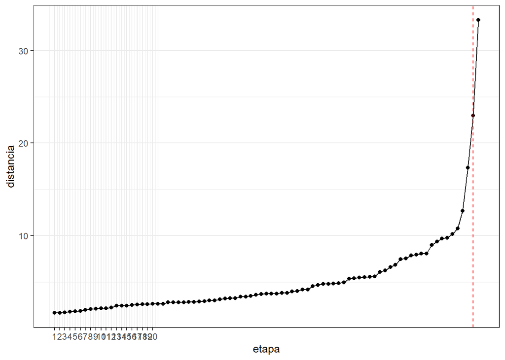

```r
#screeplot con las distancias

ggplot(alturas) + aes(x=etapa,y=distancia)  +
  geom_point() + geom_line()  +
  scale_x_continuous(breaks=seq(1,20)) +
  geom_vline(xintercept = 82,col="red",lty=2) +
  theme_bw()
```

¿como se agrupan los meses de apartir de enero 2009 hasta diciembre de 2015?

```r
# Dividir en 2 clusters

#La asignacion de cada elemento(mes) a cada cluster

grp <- cutree(res.hc, k = 2)
grp
```

```
## 2009-01-01 2009-02-01 2009-03-01 2009-04-01 2009-05-01 2009-06-01 2009-07-01
##          1          2          2          2          1          1          1
## 2009-08-01 2009-09-01 2009-10-01 2009-11-01 2009-12-01 2010-01-01 2010-02-01
##          1          1          1          1          1          2          2
## 2010-03-01 2010-04-01 2010-05-01 2010-06-01 2010-07-01 2010-08-01 2010-09-01
##          2          2          1          1          1          1          1
## 2010-10-01 2010-11-01 2010-12-01 2011-01-01 2011-02-01 2011-03-01 2011-04-01
##          1          1          2          2          2          2          2
## 2011-05-01 2011-06-01 2011-07-01 2011-08-01 2011-09-01 2011-10-01 2011-11-01
##          1          1          1          1          1          1          1
## 2011-12-01 2012-01-01 2012-02-01 2012-03-01 2012-04-01 2012-05-01 2012-06-01
##          1          1          2          2          2          1          1
## 2012-07-01 2012-08-01 2012-09-01 2012-10-01 2012-11-01 2012-12-01 2013-01-01
##          1          1          1          1          1          1          1
## 2013-02-01 2013-03-01 2013-04-01 2013-05-01 2013-06-01 2013-07-01 2013-08-01
##          1          2          1          1          1          1          1
## 2013-09-01 2013-10-01 2013-11-01 2013-12-01 2014-01-01 2014-02-01 2014-03-01
##          1          1          1          1          1          1          2
## 2014-04-01 2014-05-01 2014-06-01 2014-07-01 2014-08-01 2014-09-01 2014-10-01
##          1          1          1          1          1          1          1
## 2014-11-01 2014-12-01 2015-01-01 2015-02-01 2015-03-01 2015-04-01 2015-05-01
##          1          1          1          1          2          1          1
## 2015-06-01 2015-07-01 2015-08-01 2015-09-01 2015-10-01 2015-11-01 2015-12-01
##          1          1          1          1          1          1          1
```

```r
table(grp)
```

```
## grp
##  1  2
## 66 18
```

Hay en total 84 meses

clauster1:

hay 66 meses

cluster2:

hay 18 meses

**DEDONGRAMA**

Visualizacion de los 2 cluster:

```r
library(factoextra)
```

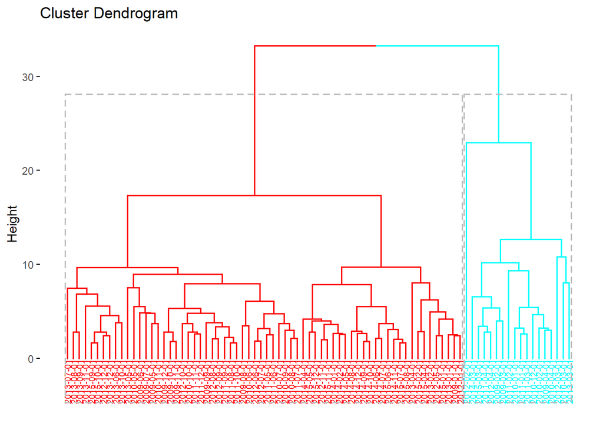

```r
fviz_dend(res.hc, k=2, cex = 0.5,
          k_colors = rainbow(2),   # Colores del arco iris
          color_labels_by_k = TRUE,
          rect=T)
```

Por el criterio del screpplot o el codo pude aver formado 4 cluster pero observando minuciosamente no me conviene formar 4 cluster, para que un solo cluster este solo un dato de igual manera sucede con 3 cluster, por eso se eligimos 2 cluster.

**GRAFICA#ACP con CLUSTER**

**GRAFICO 1**

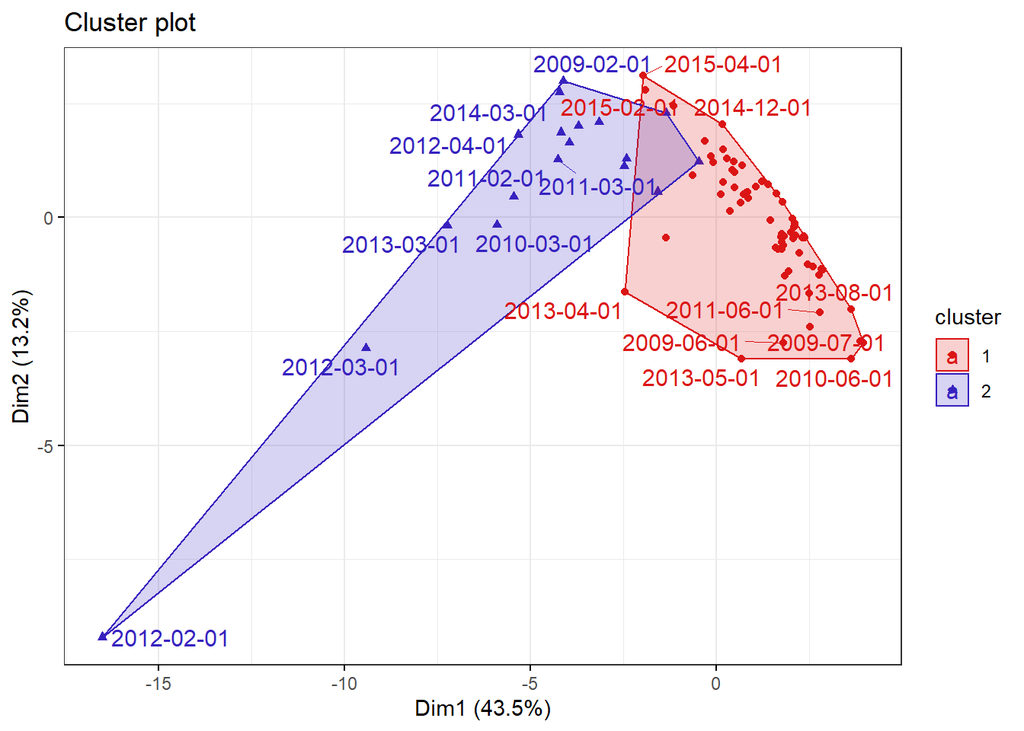

```r
#Se puede apreciar que con 2 componentes retenemos 56.7% de la inercia total y podemos explicar
#todas las variables.
library(factoextra)
fviz_cluster(list(data = datosc, cluster = grp),
             palette =c("#DB1515", "#3722BF") ,
             ellipse.type = "convex", # Concentration ellipse
             repel = T, # Avoid label overplotting (slow)
             show.clust.cent = FALSE, ggtheme = theme_bw())
```

**Insumo para un modelo predictivo como regresion lineal**

```r
# Juntando el archivo de "datos" con la columna de "cluster"
datos.j <- cbind(datosc,grp)
```

```r
#convirtiendo en factor la varaible "grp"
datos.j$grp <- factor(datos.j$grp)

#Si deseamos exportar :
# write.csv(datos.j,"Compras con Jerarquico Aglomerativo.csv")
```

**Analisis Factorial:**

En las variables(24)

ANALISIS EXPLORATORIO :

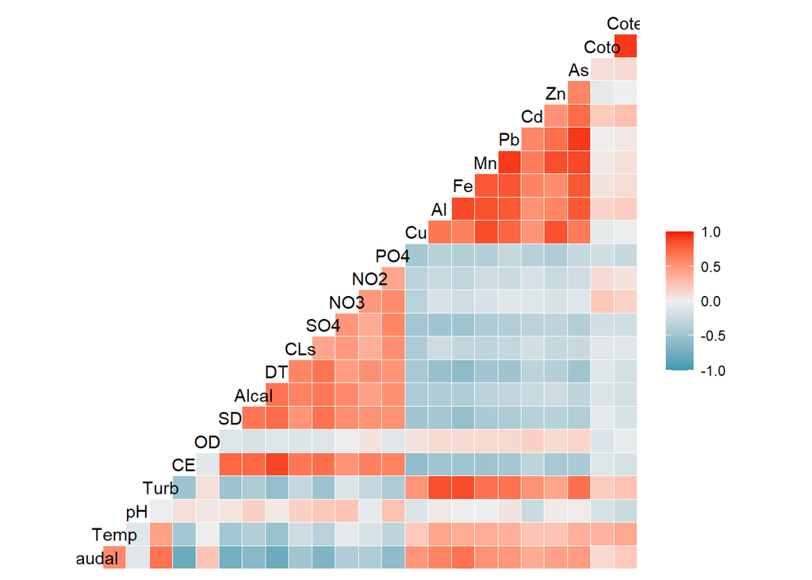

```r
library(GGally)
ggcorr(datosc)
```

```r
#Se puede observar  que entre las 24 variables,
#hay correlaciones muy altas , correlaciones altas  y correlaciones medias.
#esto podria traer problemas de multicolinealidad.
```

**Prueba de Esfericidad de Bartlett**

```r
library(rela)
library(ggplot2)
library(psych)
correlaciones<- corr.test(datosc) #correlaciones de pearson
r<-as.matrix(round(correlaciones$r,2))  #matriz de correlaciones con 2 decimales
options(scipen=999)#sin notacion cientifica
#n<-dim(datosc)   #12 filas y  24 columnas
cortest.bartlett(r,n=nrow(datosc))
```

```
## $chisq
## [1] 2057.112
##
## $p.value
## [1] 0.000000000000000000000000000000000000000000000000000000000000…
##
## $df
## [1] 276
```

Prueba de Esfericidad de Bartlett

Prueba de Esfericidad de Bartlett

Ho: |Rp|=1 (las correlaciones teóricas entre cada par de variables es nulo)

H1: |Rp|≠1 (las correlaciones teóricas entre cada par de variables NO es nulo)

conclusion:

Se rechaza la H0, se puede afirmar que las correlaciones pearson teóricas entre cada par de variables NO es nulo,es decir nuestras variables estan correlacionadas.

en otras palabras nuestra matriz correlacion pearson es diferente a la matriz identidad podemos realizar ANALISIS FACTORIAL.

```r
library(psych)
correlaciones<- corr.test(datosc) # se crea la matriz de correlaciones


#correlaciones$r                  # matriz correlaciones,las correlaciones
                                  # entre las variables son altas
Rp=det(round(correlaciones$r,2))   ;Rp
```

```
## [1] 0.0000000000009000355
```

Si la determinante de la matriz correlacion es muy pequeña pero no es cero indica que mis variables estan altamente intercorrelaciones.

https://www.uv.es/ceaces/multivari/factorial/matriz.htm

**INDICADOR KAYSER-MEYER-OlkINN KMO y MSA**

```r
library(psych)
KMO(datosc)
```

```
## Kaiser-Meyer-Olkin factor adequacy
## Call: KMO(r = datosc)
## Overall MSA =  0.85
## MSA for each item =
## Caudal   Temp     pH   Turb     CE     OD     SD  Alcal     DT    CLs    SO4
##   0.88   0.82   0.40   0.91   0.86   0.43   0.90   0.95   0.88   0.86   0.89
##    NO3    NO2    PO4     Cu     Al     Fe     Mn     Pb     Cd     Zn     As
##   0.84   0.86   0.91   0.90   0.91   0.87   0.87   0.87   0.76   0.82   0.81
##   Coto   Cote
##   0.52   0.57
```

```r
#Por otro lado el indicador "kmo" es igual 0.85
#que indica que es aceptable trabajar con 24 varaibles.
```

Se puede descartar las variables “OD” y “PH” porque es menor a 0.5 y se considera inaceptable, Pero como el ministerio de medio ambiente los utiliza frecuentemente lo vamos considerar.

Para el uso dosmestico del agua el “Ph” tiene que ser neutro por lo cual esta no se puede descartar del analisis.

```r
#datosc$OD=NULL
#datosc$pH=NULL
```

```r
KMO(datosc)
```

```
## Kaiser-Meyer-Olkin factor adequacy
## Call: KMO(r = datosc)
## Overall MSA =  0.85
## MSA for each item =
## Caudal   Temp     pH   Turb     CE     OD     SD  Alcal     DT    CLs    SO4
##   0.88   0.82   0.40   0.91   0.86   0.43   0.90   0.95   0.88   0.86   0.89
##    NO3    NO2    PO4     Cu     Al     Fe     Mn     Pb     Cd     Zn     As
##   0.84   0.86   0.91   0.90   0.91   0.87   0.87   0.87   0.76   0.82   0.81
##   Coto   Cote
##   0.52   0.57
```

```r
library(psych)
facto.con.rota <- principal(r=datosc,
                            nfactors=2,
                            rotate="varimax")#matriz de correlacion
```

Autovalores

```r
facto.con.rota$values
```

```
##  [1] 10.44788101  3.17348807  2.37946288  1.32577516  1.08324839  0.84976685
##  [7]  0.71629287  0.61416155  0.58569887  0.48016015  0.42026885  0.37266291
## [13]  0.30972691  0.27773064  0.23227188  0.15802408  0.13600920  0.11894276
## [19]  0.09583874  0.07570009  0.06083162  0.03749821  0.02731858  0.02123974
```

Cargas factoriales

```r
facto.con.rota$loadings
```

```
##
## Loadings:
##        RC1    RC2
## Caudal  0.514 -0.688
## Temp    0.382 -0.372
## pH             0.256
## Turb    0.774 -0.296
## CE     -0.376  0.837
## OD      0.160
## SD     -0.355  0.768
## Alcal  -0.211  0.814
## DT     -0.423  0.767
## CLs    -0.149  0.705
## SO4    -0.340  0.731
## NO3            0.742
## NO2    -0.121  0.624
## PO4    -0.255  0.703
## Cu      0.743 -0.312
## Al      0.882 -0.210
## Fe      0.865 -0.261
## Mn      0.949 -0.146
## Pb      0.930 -0.104
## Cd      0.701 -0.116
## Zn      0.753 -0.135
## As      0.918
## Coto    0.108
## Cote    0.148 -0.166
##
##                  RC1   RC2
## SS loadings    7.527 6.094
## Proportion Var 0.314 0.254
## Cumulative Var 0.314 0.568
```

Con 2 componentes se retiene 56.8 % de la inercia total.

¿que variables pertenecen a cada factor?

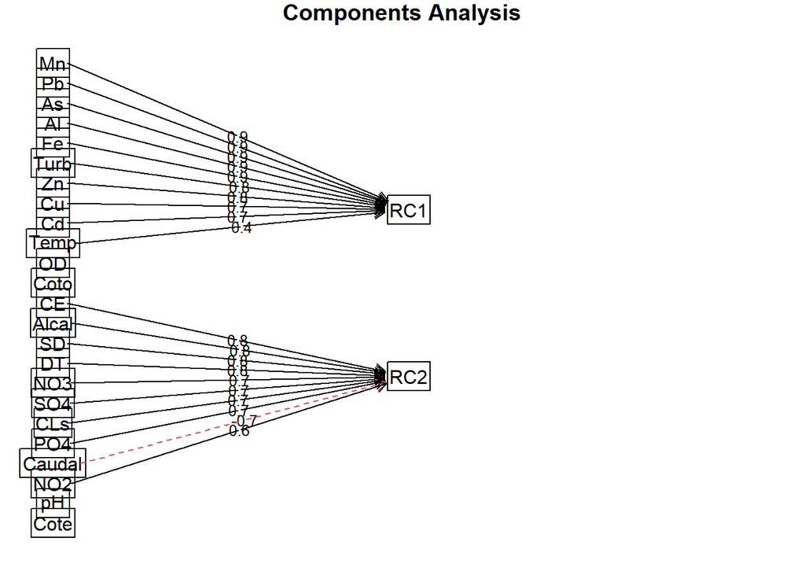

```r
library(psych)
fa.diagram(facto.con.rota)
```

```r
facto.con.rota$communality
```

```
##     Caudal       Temp         pH       Turb         CE         OD         SD
## 0.73843049 0.28456053 0.07016236 0.68594415 0.84222641 0.02858150 0.71571605
##      Alcal         DT        CLs        SO4        NO3        NO2        PO4
## 0.70666068 0.76773818 0.51914641 0.64966859 0.55174767 0.40412867 0.55862766
##         Cu         Al         Fe         Mn         Pb         Cd         Zn
## 0.64931088 0.82268191 0.81635026 0.92099658 0.87540791 0.50466635 0.58564821
##         As       Coto       Cote
## 0.85200622 0.02169933 0.04926208
```

Las variables; oxigeno disuelto(OD), coliformes termotolerables(Cote) , coliformes totales(coto), potencial de hidrogeno(Ph) no aportan mucho en mi estudio de la caliadad del agua del rio rimac dado que su comunalidad esta cerca a cero.

**CARGAS FACTORIALES**

```r
facto.con.rota$loadings
```

```
##
## Loadings:
##        RC1    RC2
## Caudal  0.514 -0.688
## Temp    0.382 -0.372
## pH             0.256
## Turb    0.774 -0.296
## CE     -0.376  0.837
## OD      0.160
## SD     -0.355  0.768
## Alcal  -0.211  0.814
## DT     -0.423  0.767
## CLs    -0.149  0.705
## SO4    -0.340  0.731
## NO3            0.742
## NO2    -0.121  0.624
## PO4    -0.255  0.703
## Cu      0.743 -0.312
## Al      0.882 -0.210
## Fe      0.865 -0.261
## Mn      0.949 -0.146
## Pb      0.930 -0.104
## Cd      0.701 -0.116
## Zn      0.753 -0.135
## As      0.918
## Coto    0.108
## Cote    0.148 -0.166
##
##                  RC1   RC2
## SS loadings    7.527 6.094
## Proportion Var 0.314 0.254
## Cumulative Var 0.314 0.568
```

**componente 1: “metaloides”**

**componente 2: “iones”**

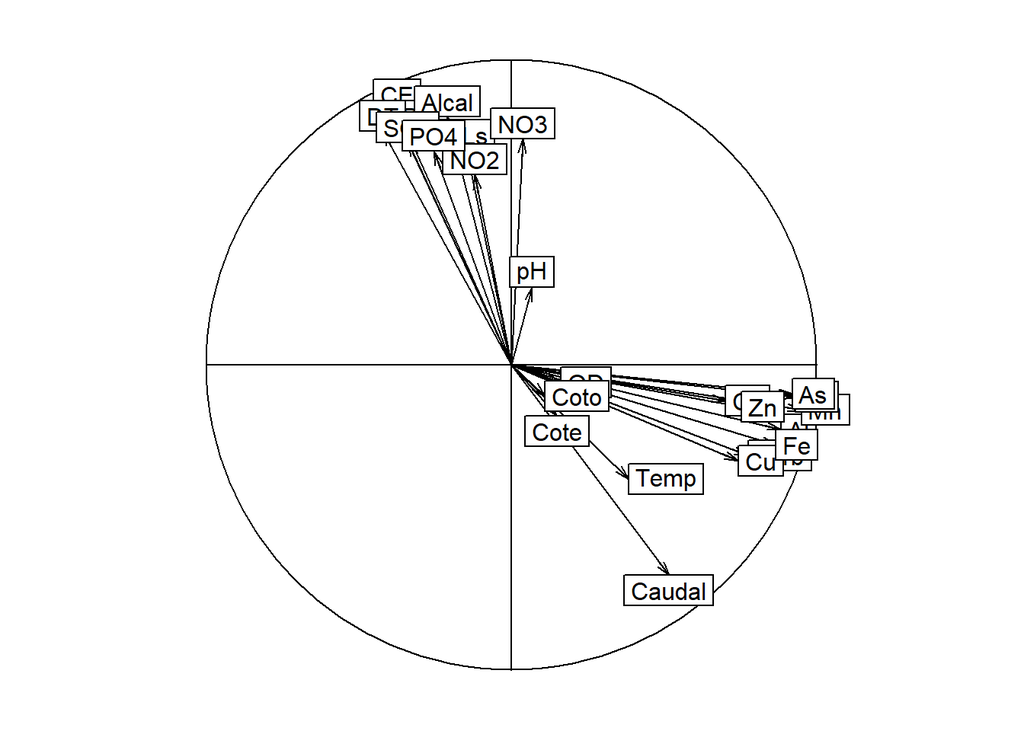

```r
library(ade4)
load <- facto.con.rota$loadings[,1:2]
s.corcircle(load,grid=FALSE)
```